# On multiple comparisons in R

Abstract

“On multiple comparisons in R” published in R News.

## Description

The multiplicity problem arises when several inferences are considered simultaneously as a group. If each inference has a 5% error rate, then the error rate over the entire group can be much higher than 5%. This article shows practical examples of multiple comparisons procedures that control the error of making any incorrect inference.

The **multcomp** package for the R statistical environment allows for multiple comparisons of parameters whose estimates are generally correlated, including comparisons of $k$ groups in general linear models. The package has many common multiple comparison procedures “hard-coded”, including Dunnett, Tukey, sequential pairwise contrasts, comparisons with the average, changepoint analysis, Williams’, Marcus’, McDermott’s, and tetrad contrasts. In addition, a free input interface for the contrast matrix allows for more general comparisons.

The comparisons themselves are not restricted to balanced or simple designs. Instead, the package is designed to provide general multiple comparisons, thus allowing for covariates, nested effects, correlated means, likelihood-based estimates, and missing values. For the homoscedastic normal linear models, the functions in the package account for the correlations between test statistics by using the exact multivariate $t$-distribution. The resulting procedures are therefore more powerful than the Bonferroni and Holm methods; adjusted p-values for these methods are reported for reference. For more general models, the program accounts for correlations using the asymptotic multivariate normal distribution; examples include multiple comparisons based on rank transformations, logistic regression, GEEs, and proportional hazards models. In the asymptotic case, the user must supply the estimates, the asymptotic covariance matrix, and the contrast matrix.

Basically, the package provides two functions. The first, `simint`, computes confidence intervals for the common single-step procedures. This approach is uniformly improved by the second function (`simtest`), which utilizes logical constraints and is closely related to closed testing. However, no confidence intervals are available for the `simtest` function. For testing and validation purposes, some examples from Westfall et al. (1999) are included in the package.

## Details

Assume the general linear model

$$\mathbf{Y} =
\mathbf{X}\boldsymbol{\beta} + \boldsymbol{\epsilon},$$

where $\mathbf{Y}$ is the $n \times 1$ observation vector, $\mathbf{X}$ is the fixed and known $n \times p$ design matrix, $\boldsymbol{\beta}$ is the fixed and unknown $p \times 1$ parameter vector and $\boldsymbol{\epsilon}$ is the random, unobservable $n \times 1$ error vector, distributed as $N_n(\mathbf{0}, \sigma^2 \mathbf{I}_n)$. We assume the usual estimates

$$\hat{\boldsymbol{\beta}} = (\mathbf{X}^t
\mathbf{X})^{-} \mathbf{X}^t \mathbf{Y}$$

and

$$\hat{\sigma}^2 = (\mathbf{Y} -
\mathbf{X}\hat{\boldsymbol{\beta}})^t (\mathbf{Y} -
\mathbf{X}\hat{\boldsymbol{\beta}}) / \nu,$$

where $\nu = n - \text{rank}(\mathbf{X})$. Our focus is on multiple comparisons for parameters of the general form $\mathbf{c}_i^t \boldsymbol{\beta}$. Its variance is given through

$$\text{Var}(\mathbf{c}_i^t
\hat{\boldsymbol{\beta}}) = \hat{\sigma}^2 \mathbf{c}_i^t (\mathbf{X}^t
\mathbf{X})^{-} \mathbf{c}_i.$$

In simultaneous inferences we are faced with a given family of estimable parameters $\{\mathbf{c}_1^t \boldsymbol{\beta}, \dots, \mathbf{c}_k^t \boldsymbol{\beta}\}$. We thus use the pivotal test statistics

$$T_i = \frac{\mathbf{c}_i^t
\hat{\boldsymbol{\beta}} - \mathbf{c}_i^t
\boldsymbol{\beta}}{\hat{\sigma} \sqrt{\mathbf{c}_i^t (\mathbf{X}^t
\mathbf{X})^{-} \mathbf{c}_i}}.$$

For a general account on multiple comparison procedures we refer to Hochberg and Tamhane (1987). The joint distribution of $\{T_1, \dots, T_k\}$ is multivariate $t$ with degrees of freedom $\nu$ and correlation matrix $\mathbf{R} = \mathbf{DC}(\mathbf{X}^t \mathbf{X})^{-} \mathbf{C}^t \mathbf{D}$, where $\mathbf{C}^t = (c_1, \dots, c_k)$ and $\mathbf{D} = \text{diag}(\mathbf{c}_i^t (\mathbf{X}^t \mathbf{X})^{-} \mathbf{c}_i)^{-1/2}$. In the asymptotic case $\nu \rightarrow \infty$ or if $\sigma$ is known, the corresponding limiting multivariate normal distribution holds. The numerical evaluation of the multivariate $t$ and normal distribution is available with the R package **mvtnorm**, see Hothorn et al. (2001).

The function `simint` provides simultaneous confidence intervals for the estimable functions $\mathbf{c}_i^t \boldsymbol{\beta}$ in the (two-sided) form

$$[\mathbf{c}_i^t \hat{\boldsymbol{\beta}}
- c_{1-\alpha} \hat{\sigma} \sqrt{\mathbf{c}_i^t (\mathbf{X}^t
\mathbf{X})^{-} \mathbf{c}_i}; \mathbf{c}_i^t \hat{\boldsymbol{\beta}} +
c_{1-\alpha} \hat{\sigma} \sqrt{\mathbf{c}_i^t (\mathbf{X}^t
\mathbf{X})^{-} \mathbf{c}_i}],$$

where $c_{1-\alpha}$ is the critical value at level $1 - \alpha$, as derived under the distributional assumptions above. If lower or upper tailed tests are used, the corresponding interval bounds are set to $-\infty$ and $\infty$, respectively.

The second function `simtest` provides more powerful test decisions than `simint` yet it does not provide simultaneous confidence intervals. It uses the stepwise methods of Westfall (1997), which take the logical constraints between the hypotheses into account and which are closely related to the closed testing principle of Marcus et al. (1976). In addition, the stochastic dependencies of the test statistics are incorporated, thus allowing imbalance, covariates and more general models. Again, any collection of linear combinations of the estimable parameters is allowed, not just pairwise comparisons. We refer to Westfall (1997) for the algebraic and algorithmic details.

### Example

We illustrate some of the capabilities of the **multcomp** package using the recovery dataset. Three different heating blankets $b_1, b_2, b_3$ for post-surgery treatment are compared to a standard blanket $b_0$. The variable of interest in this simple one-way layout was recovery time in minutes of patients allocated randomly to one of the four treatments. The standard approach for comparing several treatments against a control is the many-to-one test of Dunnett (1955). The Dunnett test is one of the “hard-coded” procedures available for one-factor models in **multcomp**. To obtain simultaneous confidence intervals for the comparisons $\beta_i - \beta_1$ on simply calls:

```
>library(multcomp)
```

Loading required package: mvtnorm

```
>data(recovery)
>Dcirec <- simint(minutes ~ blanket,
+   data = recovery, conf.level = 0.9,
+   alternative = "less")
```

```
>print(Dcirec)
```

Simultaneous confidence  
intervals: Dunnett contrasts

90 % confidence intervals

|  | Estimate | lower CI |
| --- | --- | --- |
| blanketb1-blanketb0 | -2.133 | -Inf |
| blanketb2-blanketb0 | -7.467 | -Inf |
| blanketb3-blanketb0 | -1.667 | -Inf |
|  | upper CI |  |
| blanketb1-blanketb0 | 0.822 |  |
| blanketb2-blanketb0 | -4.511 |  |
| blanketb3-blanketb0 | -0.036 |  |

A second way to obtain the same results is to define the contrast matrix $C$ explicitly:

```
>C <- matrix(c(0, 0, 0, -1, -1,
+           -1, 1, 0, 0, 0, 1, 0, 0, 0,
+           1), nc = 5)
>rownames(C) <- paste("C", 1:nrow(C),
+   sep = "")
>Ccirec <- simint(minutes ~ blanket,
+   data = recovery, conf.level = 0.9,
+   alternative = "less", eps = 1e-04,
+   cmatrix = C)

>print(Ccirec)

      Simultaneous confidence
      intervals: user-defined contrasts

      90 % confidence intervals

      Estimate lower CI upper CI
C1 -2.1333      -Inf  0.8225
C2 -7.4667      -Inf -4.5108
C3 -1.6667      -Inf -0.0360
```

The first column of $C$ stands for the intercept $\beta_0$, the remaining columns are reserved for the 4 levels $\beta_1, \dots, \beta_4$ of the single factor. Each row defines a particular linear combination $c_i^t \beta$. Note that the *eps* argument specifies the accuracy of the numerical results (see `pmvt` in package `mvtnorm` for more details). This is the reason why the confidence bounds are now printed with four significant digits instead of the former three digits.

More detailed output is available by using the summary method:

```
>summary(Ccirec)

      Simultaneous 90% confidence
      intervals: user-defined contrasts

      user-defined contrasts for factor blanket

Contrast matrix:
      [,1] [,2] [,3] [,4] [,5]
C1    0  -1    1    0    0
C2    0  -1    0    1    0
C3    0  -1    0    0    1

Absolute Error Tolerance: 1e-04

      90 % quantile: 1.8431

Coefficients:
      Estimate low CI, upp CI t value
C1 -2.1333      -Inf  0.8225 -1.3302
C2 -7.4667      -Inf -4.5108 -4.6556
C3 -1.6667      -Inf -0.0360 -1.8837
      Std.Err. p raw p Bonf p adj
C1  1.6038 0.0958 0.2874 0.2412
C2  1.6038 0.0000 0.0001 0.0001
C3  0.8848 0.0337 0.1012 0.0924
```

A more powerful approach is available using the `simtest` function. The call remains essentially the same, also no simultaneous confidence intervals are available:

[output not shown]

It transpires that the adjusted p-values are indeed uniformly lower in comparison to those from `simint`.

A final example call illustrates the use of the **multcomp** package, if the estimates $\hat{\beta}_i$ and their covariances are passed by hand. In such cases, the core functions `csimint` and `csimtest` have to be called without using the `sim{int,test}` interfaces. The call

```
>parm <- c(14.8, 12.6667, 7.3333,
+   13.1333)
>N <- c(20, 3, 3, 15)
>contrast <- contrMat(N, type = "Dunnett")
>nu <- 37
>mse <- 6.7099
```

```
>covm <- mse * diag(1/N)
>csimint(estpar = parm, df = as.integer(nu),
+     covm = covm, cmatrix = contrast,
+     conf.level = 0.9, alternative = "less")
```

```
Simultaneous confidence
intervals: user-defined contrasts
```

```
90 % confidence intervals
```

|  | Estimate | lower CI | upper CI |
| --- | --- | --- | --- |
| 2-1 | -2.133 | -Inf | 0.823 |
| 3-1 | -7.467 | -Inf | -4.511 |
| 4-1 | -1.667 | -Inf | -0.036 |

yields the same result as the first call above. The sample size vector $N$ and the mean square error *mse* are only required for a convenient computation of the covariance matrix. Note that the contrast matrix can either be entered by hand or by using the availability of standard contrast matrices in the `contrMat` function.

## Graphical Representation

The method `plot.hmtest` is available for a graphical inspectation of the simultaneous confidence intervals. For each contrast, the confidence interval is plotted, for example `plot(Dcirec)` can be used for plotting the one-sided Dunnett confidence intervals for the recovery example from the first code snippet.

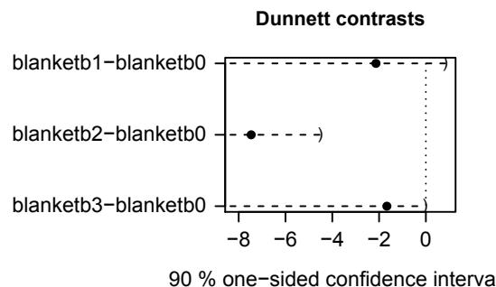

Figure 1: A graphical representation of one-sided Dunnett confidence intervals. The intervals are plotted as horizontal lines where the limits of the intervals are given by round brackets and the estimates by a point.

## Conclusion

This article addressed the application of multiple comparisons using the **multcomp** package. The present methods cover several standard test procedures and allow for user specified type of comparisons. Also the discussion has been devoted to general linear models, the package is also applicable to more general linear and nonlinear mixed models as long as the covariances between the estimates are known.

Currently, the quantiles of the multivariate $t$ or normal distribution are computed using `uniroot` on the p-value functions. This is time consuming and will be improved in future versions of the **mvtnorm** package.

## References

- Y. Hochberg and A. Tamhane. *Multiple comparison procedures*. Wiley, New York, 1987.
- T. Hothorn, F. Bretz, and A. Genz. On multivariate $t$ and Gauss probabilities in R. *R News*, 1(2):27–29, 2001.
- R. Marcus, E. Peritz, and K.B. Gabriel. On closed testing procedures with special reference to ordered analysis of variance. *Biometrika*, 63:655–660, 1976.
- P. Westfall. Multiple testing of general contrasts using logical constraints and correlations. *Journal of the American Statistical Association*, 92:299–306, 1997.
- P. H. Westfall, R. D. Tobias, D. Rom, R. D. Wolfinger, and Y. Hochberg. *Multiple Comparisons and Multiple Tests Using the SAS System*. SAS Institute Inc., Cary, NC, 1999.

We would like to thank Doug Bates for corrections and suggestions improving the readability.